# MATH2715 - Homework 2 - Normal Distrubtion

Let $X \sim N(\mu, \sigma^2).$ We define a function ‘norm’ that returns $\Pr(a < X \leq b) \text{ for all } a \leq b.$ It makes use of the inbuilt R function ‘pnorm’, which takes parameter $\alpha$ returns the value of the integral $\int_{-\infty}^{\alpha}\frac{1}{\sigma\sqrt{2\pi}} \exp\Big(-\frac{(x-\mu)^2}{2\sigma^2}\Big).$ We specifically evaluate ‘norm’ for $a=-2$ and $b=3$ where $X \sim N(1, 2^2).$

```r
norm <- function(a, b, mu, sigma) {
  #pnorm(x) returns the integral of the pdf from -inf to x.
  p <- pnorm(b, mean=mu, sd=sigma) - pnorm(a, mean=mu, sd=sigma)
  return(p)
}
norm(-2, 3, 1, 2)
```

```
[1] 0.7745375
```

Nextly, we plot the pdf and cdf of $X \sim N(1, 2^2).$ We do this by generating a sequence of values with a suitable start and endpoint. The sequence should also increment in steps of 0.1, this is adequately small to ensure the curve is smooth.

For the sequence, ‘x’, we then calculate a vector ‘freq’ which contains the value of the pdf of the normal distribution for each element in the sequence ‘x’. Plot ‘freq’ against ‘x’ to see the distribution.

For the sequence, ‘x’, calculate a new vector ‘cfreq’ which contains the value of the cdf of the normal distribution for each element in the sequence ‘x’. Plot ‘cfreq’ against ‘x’ to see the cumulative distribution.

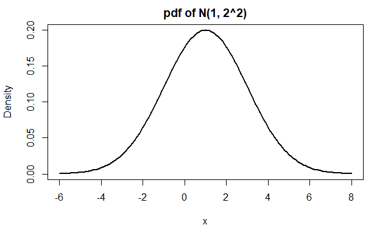

```r
x <- seq(-6, 8, by = 0.1) #increment in steps of 0.1 for a smooth curve.
freq <- dnorm(x, mean=1, sd=2)
plot(x, freq, type = "l" , ylab="Density", lwd=2, main="pdf of N(1, 2^2)")
```

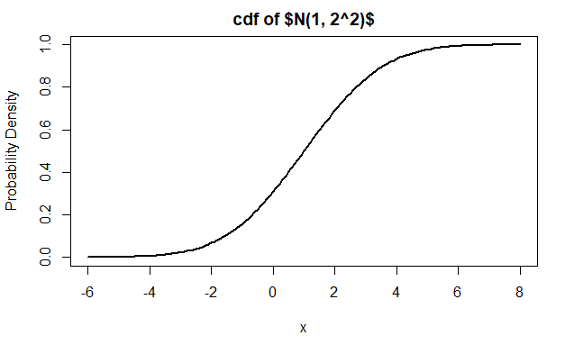

```r
cfreq <- pnorm(x, mean=1, sd=2)
plot(x, cfreq, type = "l" , ylab="Probability Density", lwd=2, main="cdf of $N(1, 2^2)$")
```

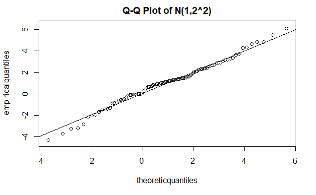

```r
quantilesample <- seq(0,1,0.01) #sample every 5th quantile
theoreticquantiles <- qnorm(quantilesample, mean=1, sd=2)
empiricalquantiles <- quantile(rnorm(100, mean=1, sd=2), probs = quantilesample)
empiricalquantiles <- as.numeric(empiricalquantiles)
plot(theoreticquantiles, empiricalquantiles, main="Q-Q Plot of N(1,2^2)")
abline(0,1) #add the line y=x
```